```python
%matplotlib inline
import matplotlib.pyplot as plt
import matplotlib as mpl
import numpy as np
```

```python
mpl.rcParams['figure.figsize'] = (8,6)
mpl.rcParams['font.size'] = 15
```

# Basic plots

## Line plots

- `x`: The x-coordinates of the lines or markers.
- `y`: The y-coordinates of the lines or markers.

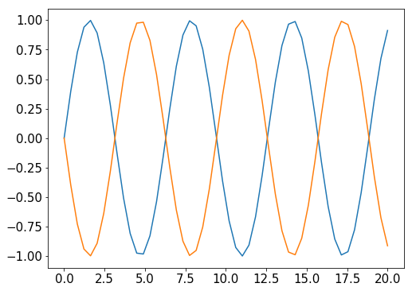

```python
x = np.linspace(0, 20)
y1 = np.sin(x)
y2 = np.sin(x - np.pi)

plt.figure()

plt.plot(x, y1)
plt.plot(x, y2);
```

**Commonly used parameters**:

- `color`: Set the color of the line.
- `linestyle`: Set the line style, e.g., solid, dashed, or none.
- `linewidth`: Set the line thickness.
- `marker`: Set the marker style, e.g., circles, triangles, or none.
- `markersize`: Set the marker size.
- `label`: Set the label for the line that will show up in the legend.

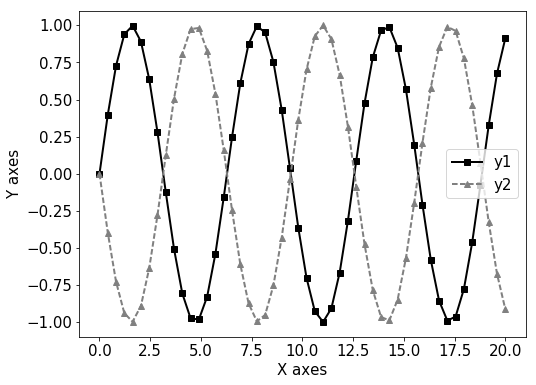

```python
x = np.linspace(0, 20)
y1 = np.sin(x)
y2 = np.sin(x - np.pi)

plt.figure()

plt.plot(x, y1, color='black', linestyle='-', linewidth=2, marker='s', markersize=6, label='y1')

plt.plot(x, y2, color='gray', linestyle='--', linewidth=2, marker='^', markersize=6, label='y2')

plt.xlabel("X axes")
plt.ylabel("Y axes")

plt.legend();
```

## Bar charts

- `left`: The x coordinate(s) of the left sides of the bars.
- `height`: The height(s) of the bars.

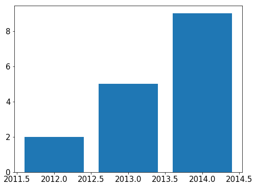

```python
years = np.arange(2012, 2015)
values = [2, 5, 9]

plt.figure()

plt.bar(years, values);
```

**Commonly used parameters**:

- `color`: Set the color of the bars.
- `edgecolor`: Set the color of the lines on the edges of the bars.
- `width`: Set the width of the bars.
- `align`: Set the alignment of the bars, e.g., center them on the x coordinate(s).
- `label`: Set the label for the bar that will show up in the legend.

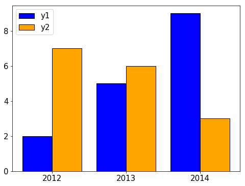

```python
years = np.arange(2012, 2015)
category1_values = [2, 5, 9]
category2_values = [7, 6, 3]

plt.figure()

plt.bar(years - 0.2, category1_values, color='blue', edgecolor='black', width=0.4, align='center', label='y1')

plt.bar(years + 0.2, category2_values, color='orange', edgecolor='black', width=0.4, align='center', label='y2')

plt.xticks(years, [str(year) for year in years])

plt.legend();
```

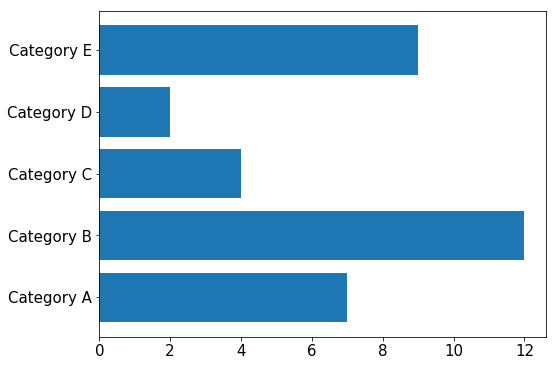

```python
categories = ['A', 'B', 'C', 'D', 'E']
values = [7, 12, 4, 2, 9]

plt.figure()

plt.barh(np.arange(len(categories)), values)

plt.yticks(np.arange(len(categories)),
           ['Category {}'.format(x) for x in categories]);
```

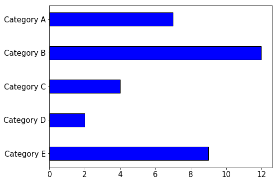

```python
categories = ['A', 'B', 'C', 'D', 'E']
values = [7, 12, 4, 2, 9]

plt.figure()

plt.barh(-np.arange(len(categories)),
         values,
         color='blue',
         edgecolor='black',
         height=0.4,
         align='center')

plt.yticks(-np.arange(len(categories)),
           ['Category {}'.format(x) for x in categories]);
```

## Pie charts

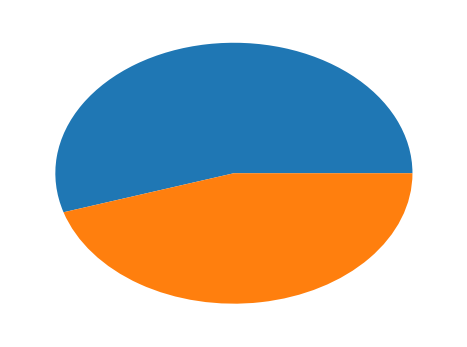

```python
counts = [17, 14]

plt.figure()

plt.pie(counts);
```

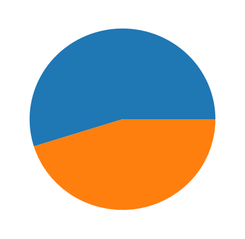

```python
counts = [17, 14]

plt.figure(figsize=(7, 7))

plt.pie(counts);
```

**Commonly used parameters**:

- `colors`: Set the colors of the wedges.
- `labels`: Set the labels of the wedges.
- `startangle`: Set the angle that the wedges start at.
- `autopct`: Set the percentage display format of the wedges.

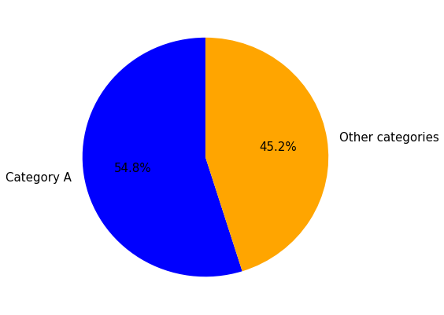

```python
counts = [17, 14]

plt.figure(figsize=(7, 7))

plt.pie(counts, colors=['blue', 'orange'], labels=['Category A', 'Other categories'],
        startangle=90, autopct='%1.1f%%');
```

## Scatter plots

- `x`, `y`: The values for the two variables.

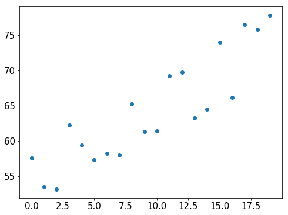

```python
x = range(20)
y = np.arange(50, 70) + (np.random.random(20) * 10.)

plt.figure()

plt.scatter(x, y);
```

**Commonly used parameters**:

- `c`: Set the color of the markers.
- `s`: Set the size of the markers.
- `marker`: Set the marker style, e.g., circles, triangles, or squares.
- `edgecolor`: Set the color of the lines on the edges of the markers.

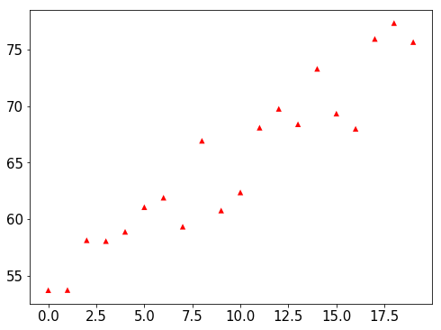

```python
x = np.arange(20)
y = np.arange(50, 70) + (np.random.random(20) * 10.)

plt.figure()

plt.scatter(x, y, c='red', s=40, marker='^', edgecolor='none');
```

## Histograms

- `x`: List of values to display the distribution of.

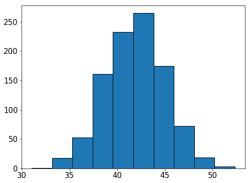

```python
column_data = np.random.normal(42, 3, 1000)

plt.figure()

plt.hist(column_data, edgecolor='black');
```

**Commonly used parameters**:

- `color`: Set the color of the bars in the histogram.
- `bins`: Set the number of bins to display in the histogram, or specify specific bins.
- `normed`: Indicate whether the bins should display fractions instead of counts.

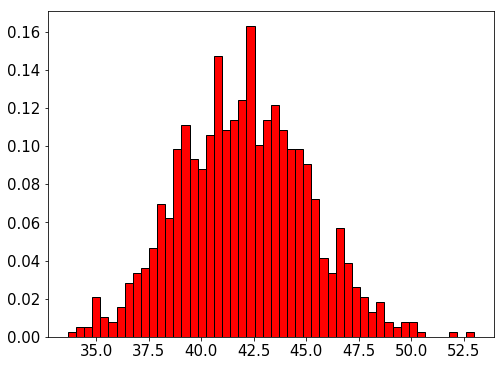

```python
column_data = np.random.normal(42, 3, 1000)

plt.figure()

plt.hist(column_data, color='red', bins=50, normed=True, edgecolor='black');
```

## Box plots

- `x`: List of values (or list of lists of values) to display the distribution of.

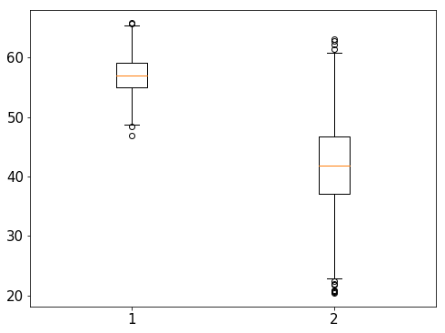

```python
two_columns_data = [np.random.normal(57, 3, 1000),
                    np.random.normal(42, 7, 1000)]

plt.boxplot(two_columns_data);
```

**Commonly used parameters**:

- `labels`: Set the labels for the box plots.
- `notch`: Indicate whether notches should be created around the median.
- `bootstrap`: Indicate whether the notches around the median should be bootstrapped.

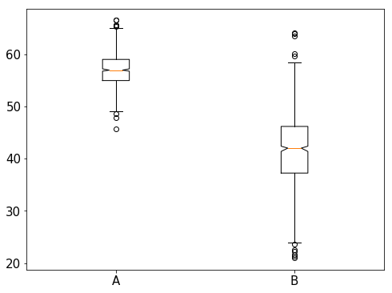

```python
two_columns_data = [np.random.normal(57, 3, 1000),
                    np.random.normal(42, 7, 1000)]

plt.boxplot(two_columns_data, labels=['A', 'B'],  notch=True, bootstrap=10000);
```

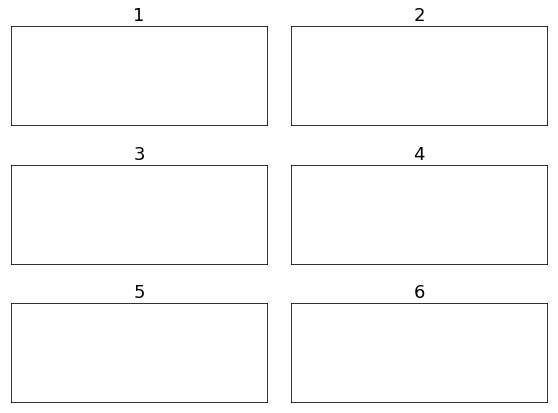

```python
plt.figure()

for i in range(1, 7):
    plt.subplot(3, 2, i)
    plt.title(i)
    plt.xticks([])
    plt.yticks([])

plt.tight_layout();
```

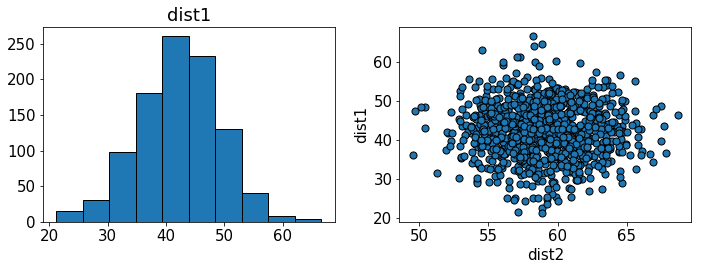

```python
dist1 = np.random.normal(42, 7, 1000)
dist2 = np.random.normal(59, 3, 1000)

plt.figure(figsize=(10, 4))

plt.subplot(1, 2, 1)
plt.hist(dist1, edgecolor='black')
plt.title('dist1')

plt.subplot(1, 2, 2)
plt.scatter(dist2, dist1, s=50, edgecolor='black')
plt.xlabel('dist2')
plt.ylabel('dist1')

plt.tight_layout();
```

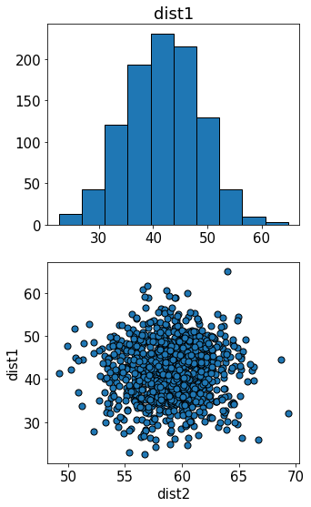

```python
dist1 = np.random.normal(42, 7, 1000)
dist2 = np.random.normal(59, 3, 1000)

plt.figure(figsize=(5, 8))

plt.subplot(2, 1, 1)
plt.hist(dist1, edgecolor='black')
plt.title('dist1')

plt.subplot(2, 1, 2)
plt.scatter(dist2, dist1, s=50, edgecolor='black')
plt.xlabel('dist2')
plt.ylabel('dist1')

plt.tight_layout();
```

## Small multiples

### Useful for comparing many categories

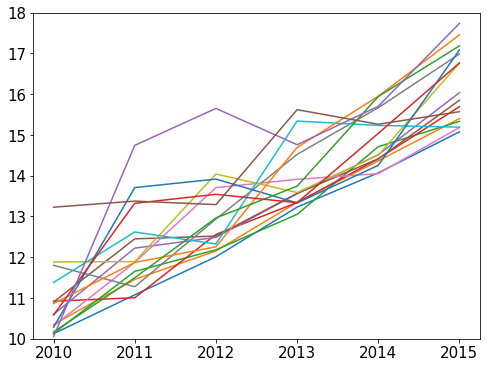

```python
years = np.arange(2010, 2016)

plt.figure()

for category_num in range(1, 17):
    y_vals = np.arange(10, 16) + (np.random.random(6) * category_num / 4.)
    plt.plot(years, y_vals)

plt.ylim(10, 18)
plt.xticks(years, [str(year) for year in years]);
```

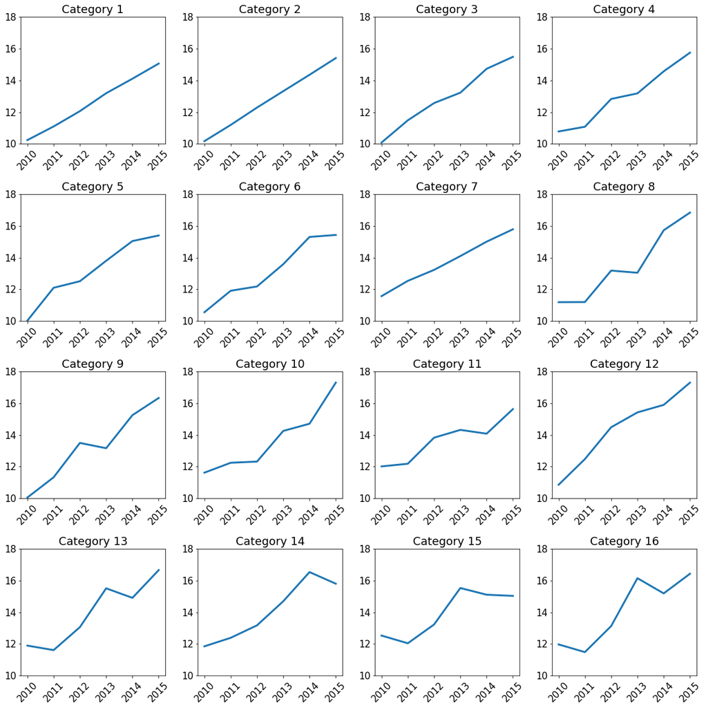

```python
years = np.arange(2010, 2016)

plt.figure(figsize=(16, 16))

for category_num in range(1, 17):
    plt.subplot(4, 4, category_num)
    y_vals = np.arange(10, 16) + (np.random.random(6) * category_num / 4.)
    plt.plot(years, y_vals, linewidth=3)
    plt.ylim(10, 18)
    plt.xticks(years, [str(year) for year in years], rotation=45, ha='center')
    plt.title('Category {}'.format(category_num))

plt.tight_layout();
```